# S_van_Mesdag_CCAs_and_ANOSIM_Barrow

Savanna van Mesdag

2023-09-16

##The following is written by Savanna van Mesdag, going through the relevant coding and analyses for CCAs and ANOSIMs for the plant and substrate data for the Barrow-in-Furness #slag bank

#setwd#

#To run the following code to carry out the analyses, the following packages must be installed#

```r
install.packages("vegan", repos = "https://github.com/vegandevs/vegan")
```

```r
install.packages("ggplot2", repos = "https://github.com/tidyverse/ggplot2")
```

#Once installed, then need to load these r packages…

```r
library(vegan)
```

```r
library(ggplot2)
```

#Loading the data files…

```r
urlfile3  <- 'https://raw.githubusercontent.com/Savannankvm/Canonical-Correspondence-analyses-six-study-sites-PhD/PhD-files/BarrowPlantSpecies.csv'

BarrowPS <-read.csv(urlfile3)

urlfile4 <- 'https://raw.githubusercontent.com/Savannankvm/Canonical-Correspondence-analyses-six-study-sites-PhD/PhD-files/BarrowPlantChemistry.csv'

BarrowPC <-read.csv(urlfile4)

head(BarrowPS)
```

```
##   Agrostis.spp. Agrostis.canina Alchemilla.mollis Alopercus.pratensis
## 1             0               0                 0                   0
## 2             0               0                 0                   0
## 3             0               0                 0                   0
## 4             0               0                 0                   0
## 5             0               0                 0                   0
## 6             0               0                 0                   0
##   Angelica.sylvestris Anthoxanthum.odoratum Anthyllis.vulneraria
## 1                   0                     0                    4
## 2                   0                     0                    0
## 3                   0                     0                  127
## 4                   0                     0                    0
## 5                   0                     0                   32
## 6                   0                     0                    0
##   Aphanes.arvensis Arrhenatherum.elatius Atrichum.undulatum Avenula.pratensis
```

[output cut: 251 more lines]

```r
head(BarrowPC)
```

```
##   pH_level SiO2 Al2O3 Fe2O3   CaO  MgO Na2O  K2O Cr2O3 TiO2  MnO P2O5  SrO  BaO
## 1    9.921 30.7  8.99  1.20 35.70 3.07 0.58 0.43 0.003 0.49 0.58 0.06 0.08 0.34
## 2    8.850 47.3 10.05  3.99 13.30 1.36 0.73 1.90 0.014 0.59 0.16 0.14 0.02 0.07
## 3    7.701 46.2 16.75  7.65  4.88 1.32 1.12 2.79 0.028 1.34 0.35 0.37 0.01 0.05
## 4    8.295 55.8  8.18  3.20 11.15 1.10 0.80 1.74 0.011 0.51 0.08 0.14 0.01 0.05
## 5    8.363 40.3 12.05  3.63 20.60 1.18 0.39 0.99 0.011 0.48 0.38 0.15 0.03 0.36
## 6    8.047 60.8  9.78  4.50  4.32 1.50 0.89 2.00 0.015 0.51 0.16 0.16 0.01 0.09
##      Ag     As     B      Be    Bi      Cd     Co     Cu    Ga    Hg    La
## 1 2e-05 0.0005 0.003 0.00103 2e-04 0.00005 0.0002 0.0028 0.001 1e-04 0.004
## 2 2e-05 0.0015 0.002 0.00021 2e-04 0.00005 0.0011 0.0044 0.001 1e-04 0.002
## 3 2e-05 0.0060 0.001 0.00011 2e-04 0.00005 0.0031 0.0097 0.001 1e-04 0.002
## 4 2e-05 0.0011 0.001 0.00007 2e-04 0.00005 0.0009 0.0037 0.001 1e-04 0.001
## 5 5e-05 0.0008 0.002 0.00058 2e-04 0.00010 0.0004 0.0032 0.001 1e-04 0.002
## 6 7e-05 0.0012 0.001 0.00015 2e-04 0.00018 0.0009 0.0041 0.001 1e-04 0.001
##      Li    Mo     Ni     Pb    S    Sb     Sc    Th    Tl     U      V     W
```

[output cut: 48 more lines]

```r
sapply(BarrowPS, class)
```

```
##               Agrostis.spp.             Agrostis.canina
##                   "integer"                   "integer"
##           Alchemilla.mollis         Alopercus.pratensis
##                   "integer"                   "integer"
##         Angelica.sylvestris       Anthoxanthum.odoratum
##                   "integer"                   "integer"
##        Anthyllis.vulneraria            Aphanes.arvensis
##                   "integer"                   "integer"
##       Arrhenatherum.elatius          Atrichum.undulatum
##                   "integer"                   "integer"
##           Avenula.pratensis             Bellis.perennis
##                   "integer"                   "integer"
##            Betula.pubescens      Blackstonia.perfoliata
##                   "integer"                   "integer"
##      Brachythecium.albicans     Brachythecium.glareosum
##                   "integer"                   "integer"
##     Brachythecium.mildeanum     Brachythecium.rutabulum
##                   "integer"                   "integer"
##                 Briza.media           Bromus.hordeaceus
##                   "integer"                   "integer"
##     Bryum.c.f..caespiticium       Bryum.c.f..pallescens
##                   "integer"                   "integer"
##             Bryum.capillare                  Bryum.spp.
##                   "integer"                   "integer"
##    Calliergonella.cupsidata           Calypogeia.arguta
##                   "integer"                   "integer"
##      Campanula.rotundifolia               Carex.distans
##                   "integer"                   "integer"
##                Carex.flacca               Carex.panicea
##                   "integer"                   "integer"
##            Carlina.vulgaris             Centaurea.nigra
##                   "integer"                   "integer"
##        Centaurium.erythraea        Centaurium.littorale
##                   "integer"                   "integer"
##       Centaurium.pulchellum          Cerastium.fontanum
##                   "integer"                   "integer"
##  Chamaenerion.angustifolium      Cirriphyllum.piliferum
##                   "integer"                   "integer"
##             Cirsium.arvense            Cirsium.palustre
##                   "integer"                   "integer"
```

[output cut: 89 more lines]

```
##                   "integer"                   "integer"
##      Trichostomum.crispulum         Trifolium.campestre
##                   "integer"                   "integer"
##            Trifolium.dubium          Trifolium.pratense
##                   "integer"                   "integer"
##            Trifolium.repens         Trisetum.flavescens
##                   "integer"                   "integer"
##           Tussilago.farfara               Urtica.diocia
##                   "integer"                   "integer"
##        Veronica.officinalis                Vicia.sativa
##                   "integer"                   "integer"
##             Viola.riviniana         Weissia.controversa
##                   "integer"                   "integer"
##           Zygodon.stirtonii
##                   "integer"
```

```r
sapply(BarrowPC, class)
```

```
##                  pH_level                      SiO2                     Al2O3
##                 "numeric"                 "numeric"                 "numeric"
##                     Fe2O3                       CaO                       MgO
##                 "numeric"                 "numeric"                 "numeric"
##                      Na2O                       K2O                     Cr2O3
##                 "numeric"                 "numeric"                 "numeric"
##                      TiO2                       MnO                      P2O5
##                 "numeric"                 "numeric"                 "numeric"
##                       SrO                       BaO                        Ag
##                 "numeric"                 "numeric"                 "numeric"
##                        As                         B                        Be
##                 "numeric"                 "numeric"                 "numeric"
##                        Bi                        Cd                        Co
##                 "numeric"                 "numeric"                 "numeric"
##                        Cu                        Ga                        Hg
##                 "numeric"                 "numeric"                 "numeric"
##                        La                        Li                        Mo
##                 "numeric"                 "numeric"                 "numeric"
##                        Ni                        Pb                         S
##                 "numeric"                 "numeric"                 "numeric"
##                        Sb                        Sc                        Th
##                 "numeric"                 "numeric"                 "numeric"
##                        Tl                         U                         V
##                 "numeric"                 "numeric"                 "numeric"
##                         W                        Zn                Akermanite
##                 "numeric"                 "numeric"                 "integer"
##                    Albite Aluminium.oxide.hydroxide                 Anhydrite
##                 "integer"                 "integer"                 "integer"
##                 Aragonite                    Augite                   Biotite
##                 "integer"                 "integer"                 "integer"
##                Birnessite                   Calcite               Clinochlore
##                 "integer"                 "integer"                 "integer"
##                 Cuspidine                  Diaspore                   Dickite
##                 "integer"                 "integer"                 "integer"
##                 Gehlenite                  Goethite                 Haematite
##                 "integer"                 "integer"                 "integer"
##                    Illite                 Kaolinite                   Langite
##                 "integer"                 "integer"                 "integer"
##                 Linnaeite           Magnesioferrite                  Melilite
##                 "integer"                 "integer"                 "integer"
##                 Merwinite                Microcline                   Mullite
##                 "integer"                 "integer"                 "integer"
##                 Muscovite                 Nitratine                Orthoclase
##                 "integer"                 "integer"                 "integer"
##             Orthopyroxene                 Periclase                 Pigeonite
##                 "integer"                 "integer"                 "integer"
##                  Phengite        Pseudowollastonite                    Quartz
##                 "integer"                 "integer"                 "integer"
##                Staurolite               Valentinite
##                 "integer"                 "integer"
```

```r
rowSums(BarrowPS)
```

```
##  [1] 132 444 446 294 277 464 328 428  82 250 155
```

```r
BarrowPSna <- na.omit(BarrowPS)

print(BarrowPS)
```

```
##    Agrostis.spp. Agrostis.canina Alchemilla.mollis Alopercus.pratensis
## 1              0               0                 0                   0
## 2              0               0                 0                   0
## 3              0               0                 0                   0
## 4              0               0                 0                   0
## 5              0               0                 0                   0
## 6              0               0                 0                   0
## 7              0               0                 0                   0
## 8              0               0                 0                   0
## 9              0               0                 0                   0
## 10             0               0                 0                   0
## 11             0               0                 0                   0
##    Angelica.sylvestris Anthoxanthum.odoratum Anthyllis.vulneraria
## 1                    0                     0                    4
## 2                    0                     0                    0
```

[output cut: 453 more lines]

#Now to do some ANOSIM tests to assess any significant differences between plant species in #different chemical variables.

#anoBSiO2 <- anosim(BarrowPS, BarrowPC$SiO2, distance = “bray”, permutations = 9999)

#When this ANOSIM is run, the error message: “there should be replicates within groups” #comes up. This error message comes up for another substrate variables for the Barrow #data. From now on, only variables that were tested successfully will be included.

```r
anoBK2O <- anosim(BarrowPS, BarrowPC$K2O, distance = "bray", permutations = 9999)

anoBK2O
```

```
##
## Call:
## anosim(x = BarrowPS, grouping = BarrowPC$K2O, permutations = 9999,      distance = "bray")
## Dissimilarity: bray
##
## ANOSIM statistic R: 0.3704
##       Significance: 0.3233
##
## Permutation: free
## Number of permutations: 9999
```

#Not statistically significant, will mention statistically significant results when #they are generated.

```r
anoBCr2O3 <- anosim(BarrowPS, BarrowPC$Cr2O3, distance = "bray", permutations = 9999)

anoBCr2O3
```

```
##
## Call:
## anosim(x = BarrowPS, grouping = BarrowPC$Cr2O3, permutations = 9999,      distance = "bray")
## Dissimilarity: bray
##
## ANOSIM statistic R: -0.009804
##       Significance: 0.5208
##
## Permutation: free
## Number of permutations: 9999
```

```r
anoBTiO2 <- anosim(BarrowPS, BarrowPC$TiO2, distance = "bray", permutations = 9999)

anoBTiO2
```

```
##
## Call:
## anosim(x = BarrowPS, grouping = BarrowPC$TiO2, permutations = 9999,      distance = "bray")
## Dissimilarity: bray
##
## ANOSIM statistic R: -0.01701
##       Significance: 0.5263
##
## Permutation: free
## Number of permutations: 9999
```

```r
anoBMnO <- anosim(BarrowPS, BarrowPC$MnO, distance = "bray", permutations = 9999)

anoBMnO
```

```
##
## Call:
## anosim(x = BarrowPS, grouping = BarrowPC$MnO, permutations = 9999,      distance = "bray")
## Dissimilarity: bray
##
## ANOSIM statistic R: 0.2051
##       Significance: 0.3281
##
## Permutation: free
## Number of permutations: 9999
```

```r
anoBP2O5 <- anosim(BarrowPS, BarrowPC$P2O5, distance = "bray", permutations = 9999)

anoBP2O5
```

```
##
## Call:
## anosim(x = BarrowPS, grouping = BarrowPC$P2O5, permutations = 9999,      distance = "bray")
## Dissimilarity: bray
##
## ANOSIM statistic R: 0.6981
##       Significance: 0.0483
##
## Permutation: free
## Number of permutations: 9999
```

```r
anoBSrO <- anosim(BarrowPS, BarrowPC$SrO, distance = "bray", permutations = 9999)

anoBSrO
```

```
##
## Call:
## anosim(x = BarrowPS, grouping = BarrowPC$SrO, permutations = 9999,      distance = "bray")
## Dissimilarity: bray
##
## ANOSIM statistic R: 0.1506
##       Significance: 0.2169
##
## Permutation: free
## Number of permutations: 9999
```

```r
anoBBaO <- anosim(BarrowPS, BarrowPC$BaO, distance = "bray", permutations = 9999)

anoBBaO
```

```
##
## Call:
## anosim(x = BarrowPS, grouping = BarrowPC$BaO, permutations = 9999,      distance = "bray")
## Dissimilarity: bray
##
## ANOSIM statistic R: 0.3333
##       Significance: 0.3464
##
## Permutation: free
## Number of permutations: 9999
```

```r
anoBAg <- anosim(BarrowPS, BarrowPC$Ag, distance = "bray", permutations = 9999)

anoBAg
```

```
##
## Call:
## anosim(x = BarrowPS, grouping = BarrowPC$Ag, permutations = 9999,      distance = "bray")
## Dissimilarity: bray
##
## ANOSIM statistic R: 0.2128
##       Significance: 0.2013
##
## Permutation: free
## Number of permutations: 9999
```

```r
anoBAs <- anosim(BarrowPS, BarrowPC$As, distance = "bray", permutations = 9999)

anoBAs
```

```
##
## Call:
## anosim(x = BarrowPS, grouping = BarrowPC$As, permutations = 9999,      distance = "bray")
## Dissimilarity: bray
##
## ANOSIM statistic R: 0.2564
##       Significance: 0.2281
##
## Permutation: free
## Number of permutations: 9999
```

```r
anoBB <- anosim(BarrowPS, BarrowPC$B, distance = "bray", permutations = 9999)

anoBB
```

```
##
## Call:
## anosim(x = BarrowPS, grouping = BarrowPC$B, permutations = 9999,      distance = "bray")
## Dissimilarity: bray
##
## ANOSIM statistic R: 0.09158
##       Significance: 0.3195
##
## Permutation: free
## Number of permutations: 9999
```

```r
anoBCd <- anosim(BarrowPS, BarrowPC$Cd, distance = "bray", permutations = 9999)

anoBCd
```

```
##
## Call:
## anosim(x = BarrowPS, grouping = BarrowPC$Cd, permutations = 9999,      distance = "bray")
## Dissimilarity: bray
##
## ANOSIM statistic R: 0.01333
##       Significance: 0.4467
##
## Permutation: free
## Number of permutations: 9999
```

```r
anoBCo <- anosim(BarrowPS, BarrowPC$Co, distance = "bray", permutations = 9999)

anoBCo
```

```
##
## Call:
## anosim(x = BarrowPS, grouping = BarrowPC$Co, permutations = 9999,      distance = "bray")
## Dissimilarity: bray
##
## ANOSIM statistic R:   0.5
##       Significance: 0.0532
##
## Permutation: free
## Number of permutations: 9999
```

```r
anoBCu <- anosim(BarrowPS, BarrowPC$Cu, distance = "bray", permutations = 9999)

anoBCu
```

```
##
## Call:
## anosim(x = BarrowPS, grouping = BarrowPC$Cu, permutations = 9999,      distance = "bray")
## Dissimilarity: bray
##
## ANOSIM statistic R: -0.4444
##       Significance: 0.7294
##
## Permutation: free
## Number of permutations: 9999
```

```r
anoBNi <- anosim(BarrowPS, BarrowPC$Ni, distance = "bray", permutations = 9999)

anoBNi
```

```
##
## Call:
## anosim(x = BarrowPS, grouping = BarrowPC$Ni, permutations = 9999,      distance = "bray")
## Dissimilarity: bray
##
## ANOSIM statistic R: 0.434
##       Significance: 0.1522
##
## Permutation: free
## Number of permutations: 9999
```

```r
anoBS <- anosim(BarrowPS, BarrowPC$S, distance = "bray", permutations = 9999)

anoBS
```

```
##
## Call:
## anosim(x = BarrowPS, grouping = BarrowPC$S, permutations = 9999,      distance = "bray")
## Dissimilarity: bray
##
## ANOSIM statistic R: -0.4444
##       Significance: 0.7264
##
## Permutation: free
## Number of permutations: 9999
```

```r
anoBSb <- anosim(BarrowPS, BarrowPC$Sb, distance = "bray", permutations = 9999)

anoBSb
```

```
##
## Call:
## anosim(x = BarrowPS, grouping = BarrowPC$Sb, permutations = 9999,      distance = "bray")
## Dissimilarity: bray
##
## ANOSIM statistic R: -0.1795
##       Significance: 0.8459
##
## Permutation: free
## Number of permutations: 9999
```

```r
anoBSc <- anosim(BarrowPS, BarrowPC$Sc, distance = "bray", permutations = 9999)

anoBSc
```

```
##
## Call:
## anosim(x = BarrowPS, grouping = BarrowPC$Sc, permutations = 9999,      distance = "bray")
## Dissimilarity: bray
##
## ANOSIM statistic R: 0.07979
##       Significance: 0.3457
##
## Permutation: free
## Number of permutations: 9999
```

```r
anoBV <- anosim(BarrowPS, BarrowPC$V, distance = "bray", permutations = 9999)

anoBV
```

```
##
## Call:
## anosim(x = BarrowPS, grouping = BarrowPC$V, permutations = 9999,      distance = "bray")
## Dissimilarity: bray
##
## ANOSIM statistic R:     1
##       Significance: 0.0188
##
## Permutation: free
## Number of permutations: 9999
```

#With two of the variables showing significant differences in different Barrow #samples, CCAs will be appropriate to demonstrate what is going on in the data.

```r
BarrowCCA <-cca(BarrowPSna, BarrowPC)

print(BarrowCCA)
```

```
## Call: cca(X = BarrowPSna, Y = BarrowPC)
##
##               Inertia Proportion Rank
## Total           4.784      1.000
## Constrained     4.784      1.000   10
## Unconstrained   0.000      0.000    0
## Inertia is scaled Chi-square
## Some constraints or conditions were aliased because they were redundant
## 88 species (variables) deleted due to missingness
##
## Eigenvalues for constrained axes:
##   CCA1   CCA2   CCA3   CCA4   CCA5   CCA6   CCA7   CCA8   CCA9  CCA10
## 0.8172 0.7282 0.6488 0.5718 0.5651 0.4823 0.3271 0.2994 0.2659 0.0785
```

```r
summary(BarrowCCA)
```

```
##
## Call:
## cca(X = BarrowPSna, Y = BarrowPC)
##
## Partitioning of scaled Chi-square:
##               Inertia Proportion
## Total           4.784          1
## Constrained     4.784          1
## Unconstrained   0.000          0
##
## Eigenvalues, and their contribution to the scaled Chi-square
##
## Importance of components:
##                         CCA1   CCA2   CCA3   CCA4   CCA5   CCA6    CCA7    CCA8
## Eigenvalue            0.8172 0.7282 0.6488 0.5718 0.5651 0.4823 0.32715 0.29937
## Proportion Explained  0.1708 0.1522 0.1356 0.1195 0.1181 0.1008 0.06838 0.06257
## Cumulative Proportion 0.1708 0.3230 0.4586 0.5781 0.6962 0.7970 0.86542 0.92800
##                          CCA9   CCA10
## Eigenvalue            0.26594 0.07853
## Proportion Explained  0.05559 0.01641
## Cumulative Proportion 0.98359 1.00000
##
## Accumulated constrained eigenvalues
## Importance of components:
##                         CCA1   CCA2   CCA3   CCA4   CCA5   CCA6    CCA7    CCA8
## Eigenvalue            0.8172 0.7282 0.6488 0.5718 0.5651 0.4823 0.32715 0.29937
## Proportion Explained  0.1708 0.1522 0.1356 0.1195 0.1181 0.1008 0.06838 0.06257
## Cumulative Proportion 0.1708 0.3230 0.4586 0.5781 0.6962 0.7970 0.86542 0.92800
##                          CCA9   CCA10
## Eigenvalue            0.26594 0.07853
## Proportion Explained  0.05559 0.01641
## Cumulative Proportion 0.98359 1.00000
##
## Scaling 2 for species and site scores
## * Species are scaled proportional to eigenvalues
## * Sites are unscaled: weighted dispersion equal on all dimensions
##
##
## Species scores
##
```

[output cut: 144 more lines]

```
##
##
## Biplot scores for constraining variables
##
##             CCA1     CCA2    CCA3     CCA4      CCA5    CCA6
## pH_level  0.5409 -0.55284 -0.3393 -0.02356 -0.107789  0.3613
## SiO2      0.5260  0.38241  0.1927  0.08485  0.140277 -0.6578
## Al2O3    -0.3793  0.04361  0.7455 -0.24088 -0.253990 -0.1128
## Fe2O3    -0.1365  0.38611  0.6937 -0.25608 -0.171006 -0.2150
## CaO      -0.2782 -0.46366 -0.5098  0.06793  0.007037  0.5595
## MgO      -0.1018 -0.43536 -0.6576 -0.19389 -0.255306 -0.2811
## Na2O      0.1336  0.44817  0.3630 -0.37350 -0.295273 -0.4636
## K2O       0.1463  0.50713  0.5940 -0.29340 -0.244142 -0.3163
## Cr2O3    -0.1190  0.39658  0.6810 -0.32211 -0.202999 -0.1676
## TiO2     -0.3467  0.26297  0.6041 -0.37116 -0.396173 -0.1179
```

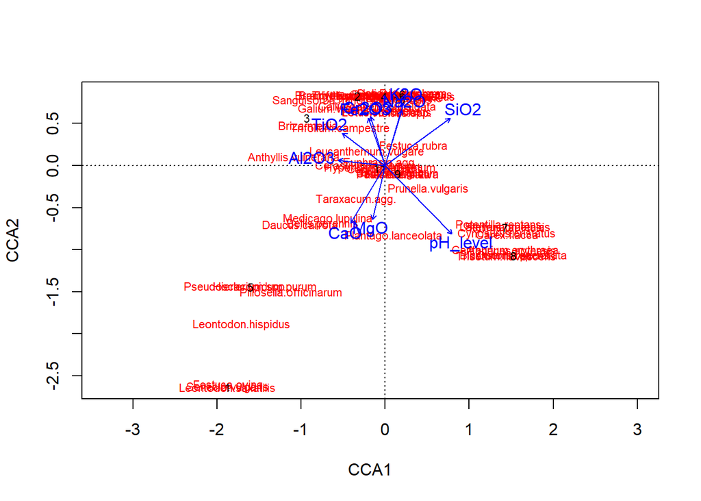

```r
plot(BarrowCCA)
```

#This CCA uses all of the plant data and substrate data. As before, substrate samples will #be selected for CCAs that can be further examined using anova tests.

```r
BarrowCCA1.1 <-cca(BarrowPSna ~ pH_level + CaO + MgO + K2O + MgO + Al2O3 + Cr2O3,
data = BarrowPC)

print(BarrowCCA1.1)
```

```
## Call: cca(formula = BarrowPSna ~ pH_level + CaO + MgO + K2O + MgO +
## Al2O3 + Cr2O3, data = BarrowPC)
##
##               Inertia Proportion Rank
## Total          4.7843     1.0000
## Constrained    3.3955     0.7097    6
## Unconstrained  1.3888     0.2903    4
## Inertia is scaled Chi-square
## 88 species (variables) deleted due to missingness
##
## Eigenvalues for constrained axes:
##   CCA1   CCA2   CCA3   CCA4   CCA5   CCA6
## 0.8007 0.6694 0.6292 0.5458 0.4629 0.2875
##
## Eigenvalues for unconstrained axes:
##    CA1    CA2    CA3    CA4
## 0.5421 0.3504 0.2938 0.2025
```

```r
summary(BarrowCCA1.1)
```

```
##
## Call:
## cca(formula = BarrowPSna ~ pH_level + CaO + MgO + K2O + MgO +      Al2O3 + Cr2O3, data = BarrowPC)
##
## Partitioning of scaled Chi-square:
##               Inertia Proportion
## Total           4.784     1.0000
## Constrained     3.395     0.7097
## Unconstrained   1.389     0.2903
##
## Eigenvalues, and their contribution to the scaled Chi-square
##
## Importance of components:
##                         CCA1   CCA2   CCA3   CCA4    CCA5   CCA6    CA1     CA2
## Eigenvalue            0.8007 0.6694 0.6292 0.5458 0.46287 0.2875 0.5421 0.35042
## Proportion Explained  0.1674 0.1399 0.1315 0.1141 0.09675 0.0601 0.1133 0.07324
## Cumulative Proportion 0.1674 0.3073 0.4388 0.5529 0.64961 0.7097 0.8230 0.89626
##                           CA3     CA4
## Eigenvalue            0.29381 0.20250
## Proportion Explained  0.06141 0.04233
## Cumulative Proportion 0.95767 1.00000
##
## Accumulated constrained eigenvalues
## Importance of components:
##                         CCA1   CCA2   CCA3   CCA4   CCA5    CCA6
## Eigenvalue            0.8007 0.6694 0.6292 0.5458 0.4629 0.28751
## Proportion Explained  0.2358 0.1971 0.1853 0.1607 0.1363 0.08468
## Cumulative Proportion 0.2358 0.4330 0.6183 0.7790 0.9153 1.00000
##
## Scaling 2 for species and site scores
## * Species are scaled proportional to eigenvalues
## * Sites are unscaled: weighted dispersion equal on all dimensions
##
##
## Species scores
##
##                                  CCA1     CCA2       CCA3     CCA4      CCA5
## Anthyllis.vulneraria        -1.067437 -0.14054  1.3490999  0.76691 -0.130564
## Aphanes.arvensis             1.525735 -1.16390  0.1447032  0.40303 -0.091237
## Arrhenatherum.elatius        0.088200  0.72375 -0.4207094 -0.95472 -0.649996
```

[output cut: 136 more lines]

```
## 8   1.533438 -1.3707  0.18600  0.4379 -0.093114  0.61418
## 9  -0.169927  1.3379 -0.45395 -0.1574  4.959357 -0.79181
## 10  0.265958  0.5748 -0.75858 -1.0348 -0.041000 -2.09531
## 11 -0.494936 -0.7203 -1.42650  0.7144  1.816196  0.32123
##
##
## Biplot scores for constraining variables
##
##              CCA1    CCA2    CCA3   CCA4    CCA5      CCA6
## pH_level  0.51655 -0.4253 -0.5350 0.2316  0.4609 -0.003609
## CaO      -0.32828 -0.3247 -0.5923 0.0893  0.6491  0.081775
## MgO      -0.13624 -0.1800 -0.7891 0.3633 -0.2815 -0.339377
## K2O       0.19862  0.3935  0.7146 0.2671 -0.4683 -0.066534
## Al2O3    -0.33311 -0.1285  0.7587 0.3944 -0.3282 -0.183356
## Cr2O3    -0.07184  0.2590  0.8031 0.3117 -0.3599 -0.236769
```

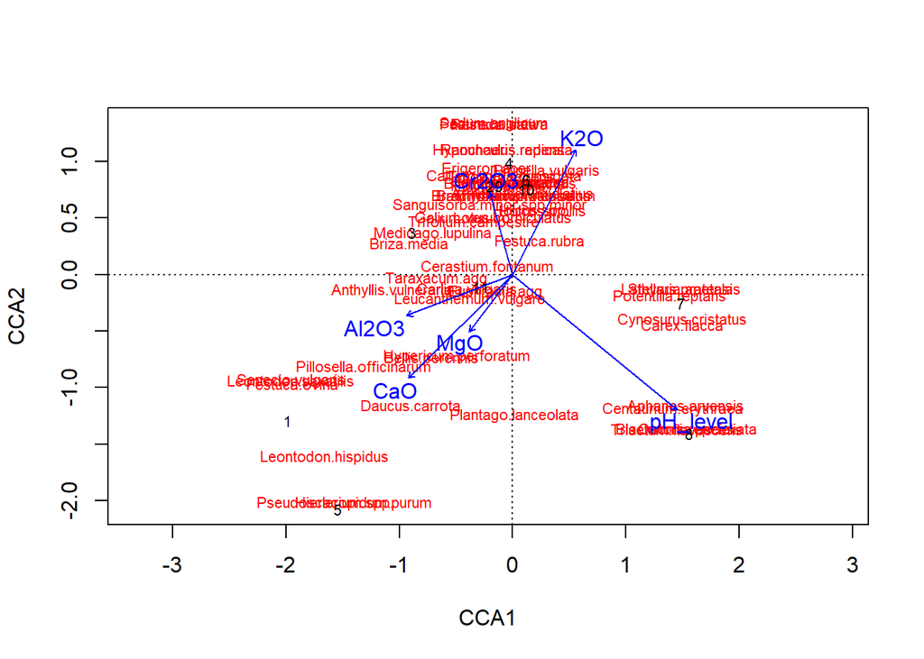

```r
plot(BarrowCCA1.1)
```

```r
anova(BarrowCCA1.1)
```

```
## Permutation test for cca under reduced model
## Permutation: free
## Number of permutations: 999
##
## Model: cca(formula = BarrowPSna ~ pH_level + CaO + MgO + K2O + MgO + Al2O3 + Cr2O3, data = BarrowPC)
##          Df ChiSquare      F Pr(>F)
## Model     6    3.3955 1.6299  0.001 ***
## Residual  4    1.3888
## ---
## Signif. codes:  0 '***' 0.001 '**' 0.01 '*' 0.05 '.' 0.1 ' ' 1
```

#F statistic of 1.6299 and p value of 0.001.

```r
BarrowCCA1.2 <-cca(BarrowPSna ~ pH_level + CaO + K2O + Al2O3 + Pb + BaO + Calcite,
                   data = BarrowPC)

print(BarrowCCA1.2)
```

```
## Call: cca(formula = BarrowPSna ~ pH_level + CaO + K2O + Al2O3 + Pb +
## BaO + Calcite, data = BarrowPC)
##
##               Inertia Proportion Rank
## Total          4.7843     1.0000
## Constrained    3.8216     0.7988    7
## Unconstrained  0.9627     0.2012    3
## Inertia is scaled Chi-square
## 88 species (variables) deleted due to missingness
##
## Eigenvalues for constrained axes:
##   CCA1   CCA2   CCA3   CCA4   CCA5   CCA6   CCA7
## 0.7990 0.7092 0.6201 0.5655 0.4759 0.3491 0.3027
##
## Eigenvalues for unconstrained axes:
##    CA1    CA2    CA3
## 0.4930 0.3464 0.1232
```

```r
summary(BarrowCCA1.2)
```

```
##
## Call:
## cca(formula = BarrowPSna ~ pH_level + CaO + K2O + Al2O3 + Pb +      BaO + Calcite, data = BarrowPC)
##
## Partitioning of scaled Chi-square:
##               Inertia Proportion
## Total          4.7843     1.0000
## Constrained    3.8216     0.7988
## Unconstrained  0.9627     0.2012
##
## Eigenvalues, and their contribution to the scaled Chi-square
##
## Importance of components:
##                        CCA1   CCA2   CCA3   CCA4    CCA5    CCA6    CCA7    CA1
## Eigenvalue            0.799 0.7092 0.6201 0.5655 0.47594 0.34914 0.30269 0.4930
## Proportion Explained  0.167 0.1482 0.1296 0.1182 0.09948 0.07298 0.06327 0.1031
## Cumulative Proportion 0.167 0.3152 0.4449 0.5630 0.66253 0.73551 0.79877 0.9018
##                           CA2     CA3
## Eigenvalue            0.34644 0.12325
## Proportion Explained  0.07241 0.02576
## Cumulative Proportion 0.97424 1.00000
##
## Accumulated constrained eigenvalues
## Importance of components:
##                         CCA1   CCA2   CCA3   CCA4   CCA5    CCA6    CCA7
## Eigenvalue            0.7990 0.7092 0.6201 0.5655 0.4759 0.34914 0.30269
## Proportion Explained  0.2091 0.1856 0.1623 0.1480 0.1245 0.09136 0.07921
## Cumulative Proportion 0.2091 0.3947 0.5569 0.7049 0.8294 0.92079 1.00000
##
## Scaling 2 for species and site scores
## * Species are scaled proportional to eigenvalues
## * Sites are unscaled: weighted dispersion equal on all dimensions
##
##
## Species scores
##
##                                 CCA1     CCA2      CCA3     CCA4    CCA5
## Anthyllis.vulneraria        -1.16083  0.19754 -1.257657  0.62975  0.0880
## Aphanes.arvensis             1.30676 -1.32791 -0.752484 -0.28887 -0.4848
## Arrhenatherum.elatius        0.33240  0.76097  0.667351 -0.87383  0.5682
```

[output cut: 137 more lines]

```
## 9  -0.44155  0.3285  2.7555  1.04976 -3.67977  0.02211
## 10  0.43908  0.3224  0.9711 -0.59938  0.75036 -0.76285
## 11 -0.13473  0.2941  1.0888  0.07925 -1.43109 -2.14477
##
##
## Biplot scores for constraining variables
##
##             CCA1     CCA2    CCA3     CCA4    CCA5     CCA6
## pH_level  0.4665 -0.60972  0.3825  0.13667 -0.4070 -0.10630
## CaO      -0.3508 -0.37609  0.5910  0.06822 -0.5118 -0.05873
## K2O       0.2205  0.43233 -0.7256  0.24325  0.2715  0.00289
## Al2O3    -0.3815  0.04666 -0.8136  0.22687  0.1545 -0.25118
## Pb        0.3138  0.05571  0.2341 -0.70609  0.3865 -0.24612
## BaO      -0.3427 -0.38636  0.5341 -0.16222 -0.1776 -0.45889
## Calcite  -0.4337 -0.22700 -0.3955  0.12717 -0.5723  0.37289
```

```r
anova(BarrowCCA1.2)
```

```
## Permutation test for cca under reduced model
## Permutation: free
## Number of permutations: 999
##
## Model: cca(formula = BarrowPSna ~ pH_level + CaO + K2O + Al2O3 + Pb + BaO + Calcite, data = BarrowPC)
##          Df ChiSquare      F Pr(>F)
## Model     7    3.8216 1.7012  0.001 ***
## Residual  3    0.9627
## ---
## Signif. codes:  0 '***' 0.001 '**' 0.01 '*' 0.05 '.' 0.1 ' ' 1
```

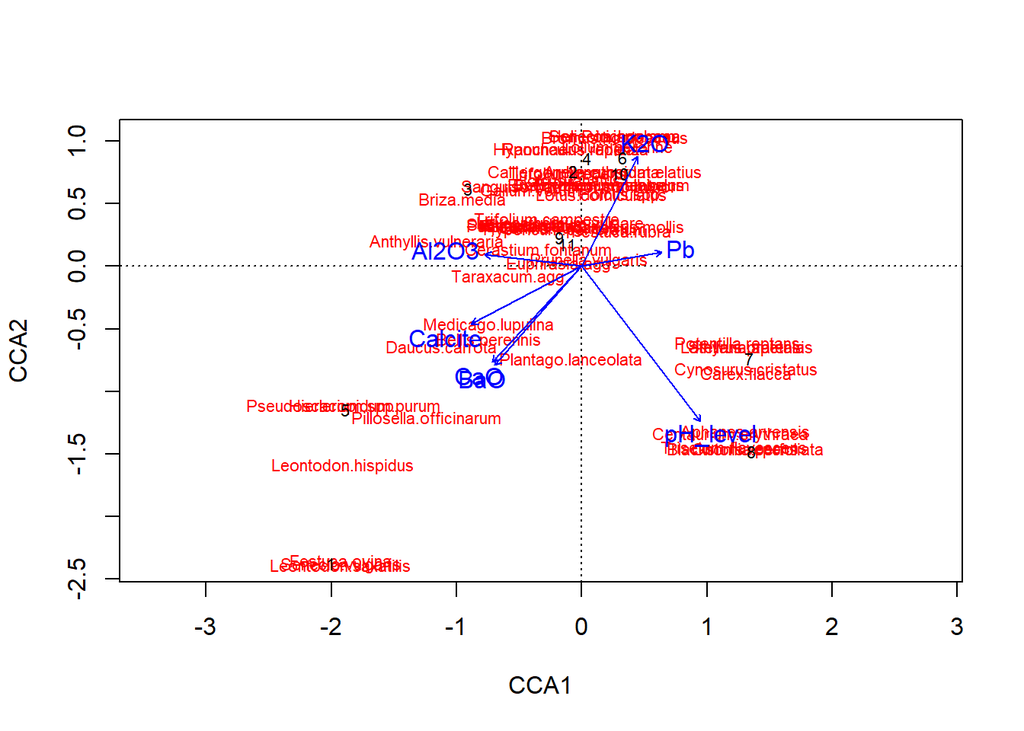

```r
plot(BarrowCCA1.2)
```

#F statistic of 1.7012 and p value of 0.001

```r
BarrowCCA1.3 <-cca(BarrowPSna ~ pH_level + Cd + K2O + Al2O3 + Pb + BaO + Calcite,
                   data = BarrowPC)

print(BarrowCCA1.3)
```

```
## Call: cca(formula = BarrowPSna ~ pH_level + Cd + K2O + Al2O3 + Pb + BaO
## + Calcite, data = BarrowPC)
##
##               Inertia Proportion Rank
## Total          4.7843     1.0000
## Constrained    3.8362     0.8018    7
## Unconstrained  0.9480     0.1982    3
## Inertia is scaled Chi-square
## 88 species (variables) deleted due to missingness
##
## Eigenvalues for constrained axes:
##   CCA1   CCA2   CCA3   CCA4   CCA5   CCA6   CCA7
## 0.7991 0.6805 0.6276 0.5650 0.5008 0.3450 0.3182
##
## Eigenvalues for unconstrained axes:
##    CA1    CA2    CA3
## 0.4331 0.3699 0.1451
```

```r
summary(BarrowCCA1.3)
```

```
##
## Call:
## cca(formula = BarrowPSna ~ pH_level + Cd + K2O + Al2O3 + Pb +      BaO + Calcite, data = BarrowPC)
##
## Partitioning of scaled Chi-square:
##               Inertia Proportion
## Total           4.784     1.0000
## Constrained     3.836     0.8018
## Unconstrained   0.948     0.1982
##
## Eigenvalues, and their contribution to the scaled Chi-square
##
## Importance of components:
##                         CCA1   CCA2   CCA3   CCA4   CCA5    CCA6   CCA7     CA1
## Eigenvalue            0.7991 0.6805 0.6276 0.5650 0.5008 0.34504 0.3182 0.43314
## Proportion Explained  0.1670 0.1422 0.1312 0.1181 0.1047 0.07212 0.0665 0.09053
## Cumulative Proportion 0.1670 0.3093 0.4405 0.5586 0.6632 0.73534 0.8018 0.89238
##                           CA2     CA3
## Eigenvalue            0.36985 0.14506
## Proportion Explained  0.07731 0.03032
## Cumulative Proportion 0.96968 1.00000
##
## Accumulated constrained eigenvalues
## Importance of components:
##                         CCA1   CCA2   CCA3   CCA4   CCA5    CCA6    CCA7
## Eigenvalue            0.7991 0.6805 0.6276 0.5650 0.5008 0.34504 0.31815
## Proportion Explained  0.2083 0.1774 0.1636 0.1473 0.1305 0.08994 0.08293
## Cumulative Proportion 0.2083 0.3857 0.5493 0.6966 0.8271 0.91707 1.00000
##
## Scaling 2 for species and site scores
## * Species are scaled proportional to eigenvalues
## * Sites are unscaled: weighted dispersion equal on all dimensions
##
##
## Species scores
##
##                                 CCA1     CCA2     CCA3      CCA4     CCA5
## Anthyllis.vulneraria        -1.16852  0.50376  1.04805 -0.612232 -0.30236
## Aphanes.arvensis             1.19245 -1.18842  1.04055  0.359000 -0.45058
## Arrhenatherum.elatius        0.44900  0.53880 -0.90634  0.825596  0.25578
```

[output cut: 137 more lines]

```
## 9   0.03303 -1.7155 -2.0751 -0.84913 -1.3154  0.365417
## 10  0.44693  0.1966 -0.8774  0.54754  1.0595 -0.131423
## 11  0.03890 -0.2449 -1.2196 -0.05582 -0.7865  3.378425
##
##
## Biplot scores for constraining variables
##
##             CCA1     CCA2    CCA3     CCA4      CCA5    CCA6
## pH_level  0.4467 -0.77197 -0.1246 -0.10565 -0.002455  0.4216
## Cd        0.2494  0.13349 -0.3281  0.57790  0.293287 -0.5161
## K2O       0.2158  0.61253  0.5710 -0.24998 -0.050559 -0.4278
## Al2O3    -0.4114  0.27566  0.7294 -0.21774 -0.067634 -0.2880
## Pb        0.3088  0.05032 -0.2167  0.68754  0.398587 -0.4195
## BaO      -0.3473 -0.50394 -0.3840  0.16981  0.180891  0.5279
## Calcite  -0.4410 -0.18410  0.3834 -0.09465 -0.560866  0.4308
```

```r
anova(BarrowCCA1.3)
```

```
## Permutation test for cca under reduced model
## Permutation: free
## Number of permutations: 999
##
## Model: cca(formula = BarrowPSna ~ pH_level + Cd + K2O + Al2O3 + Pb + BaO + Calcite, data = BarrowPC)
##          Df ChiSquare      F Pr(>F)
## Model     7    3.8362 1.7342  0.002 **
## Residual  3    0.9480
## ---
## Signif. codes:  0 '***' 0.001 '**' 0.01 '*' 0.05 '.' 0.1 ' ' 1
```

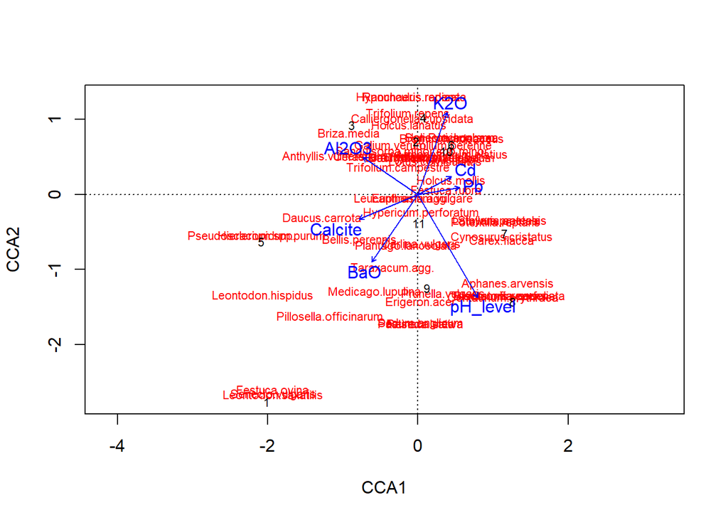

```r
plot(BarrowCCA1.3)
```

```r
BarrowCCA1.4 <-cca(BarrowPSna ~ pH_level + K2O + Al2O3 + BaO + Calcite,
                   data = BarrowPC)

print(BarrowCCA1.4)
```

```
## Call: cca(formula = BarrowPSna ~ pH_level + K2O + Al2O3 + BaO +
## Calcite, data = BarrowPC)
##
##               Inertia Proportion Rank
## Total          4.7843     1.0000
## Constrained    2.7935     0.5839    5
## Unconstrained  1.9908     0.4161    5
## Inertia is scaled Chi-square
## 88 species (variables) deleted due to missingness
##
## Eigenvalues for constrained axes:
##   CCA1   CCA2   CCA3   CCA4   CCA5
## 0.7867 0.6796 0.6052 0.3846 0.3373
##
## Eigenvalues for unconstrained axes:
##    CA1    CA2    CA3    CA4    CA5
## 0.6168 0.5222 0.4209 0.3203 0.1106
```

```r
summary(BarrowCCA1.4)
```

```
##
## Call:
## cca(formula = BarrowPSna ~ pH_level + K2O + Al2O3 + BaO + Calcite,      data = BarrowPC)
##
## Partitioning of scaled Chi-square:
##               Inertia Proportion
## Total           4.784     1.0000
## Constrained     2.793     0.5839
## Unconstrained   1.991     0.4161
##
## Eigenvalues, and their contribution to the scaled Chi-square
##
## Importance of components:
##                         CCA1   CCA2   CCA3   CCA4    CCA5    CA1    CA2     CA3
## Eigenvalue            0.7867 0.6796 0.6052 0.3846 0.33727 0.6168 0.5222 0.42092
## Proportion Explained  0.1644 0.1421 0.1265 0.0804 0.07049 0.1289 0.1092 0.08798
## Cumulative Proportion 0.1644 0.3065 0.4330 0.5134 0.58388 0.7128 0.8220 0.90994
##                           CA4     CA5
## Eigenvalue            0.32029 0.11059
## Proportion Explained  0.06695 0.02311
## Cumulative Proportion 0.97689 1.00000
##
## Accumulated constrained eigenvalues
## Importance of components:
##                         CCA1   CCA2   CCA3   CCA4   CCA5
## Eigenvalue            0.7867 0.6796 0.6052 0.3846 0.3373
## Proportion Explained  0.2816 0.2433 0.2166 0.1377 0.1207
## Cumulative Proportion 0.2816 0.5249 0.7416 0.8793 1.0000
##
## Scaling 2 for species and site scores
## * Species are scaled proportional to eigenvalues
## * Sites are unscaled: weighted dispersion equal on all dimensions
##
##
## Species scores
##
##                                  CCA1     CCA2     CCA3     CCA4     CCA5
## Anthyllis.vulneraria        -1.119964  0.50147 -1.30702  0.57848  0.28028
## Aphanes.arvensis             0.962645 -1.18723 -0.87172 -0.21889 -0.22730
## Arrhenatherum.elatius        0.329566  0.59583  1.08518  0.94444 -0.26032
```

[output cut: 135 more lines]

```
## 7   1.491448 -0.5591 -0.0566  1.2789  0.4315 -0.30956
## 8   0.856885 -1.3128 -1.0347 -0.5185 -0.3591  1.28640
## 9   0.153406 -1.6595  1.1757 -1.4772 -0.1935 -0.77902
## 10  0.455077  0.1901  1.2405  0.8905  0.3601  0.09206
## 11 -0.004252 -0.1764  0.8331 -1.2284  3.9324 -0.57945
##
##
## Biplot scores for constraining variables
##
##             CCA1    CCA2    CCA3     CCA4     CCA5 CA1
## pH_level  0.4421 -0.7847  0.1028 -0.27699  0.31859   0
## K2O       0.2349  0.5894 -0.6465  0.33304 -0.26181   0
## Al2O3    -0.4103  0.2677 -0.7767  0.39592 -0.00487   0
## BaO      -0.3573 -0.4871  0.4670 -0.04498  0.64420   0
## Calcite  -0.4691 -0.1684 -0.4890 -0.71450  0.04509   0
```

```r
anova(BarrowCCA1.4)
```

```
## Permutation test for cca under reduced model
## Permutation: free
## Number of permutations: 999
##
## Model: cca(formula = BarrowPSna ~ pH_level + K2O + Al2O3 + BaO + Calcite, data = BarrowPC)
##          Df ChiSquare      F Pr(>F)
## Model     5    2.7935 1.4032  0.003 **
## Residual  5    1.9908
## ---
## Signif. codes:  0 '***' 0.001 '**' 0.01 '*' 0.05 '.' 0.1 ' ' 1
```

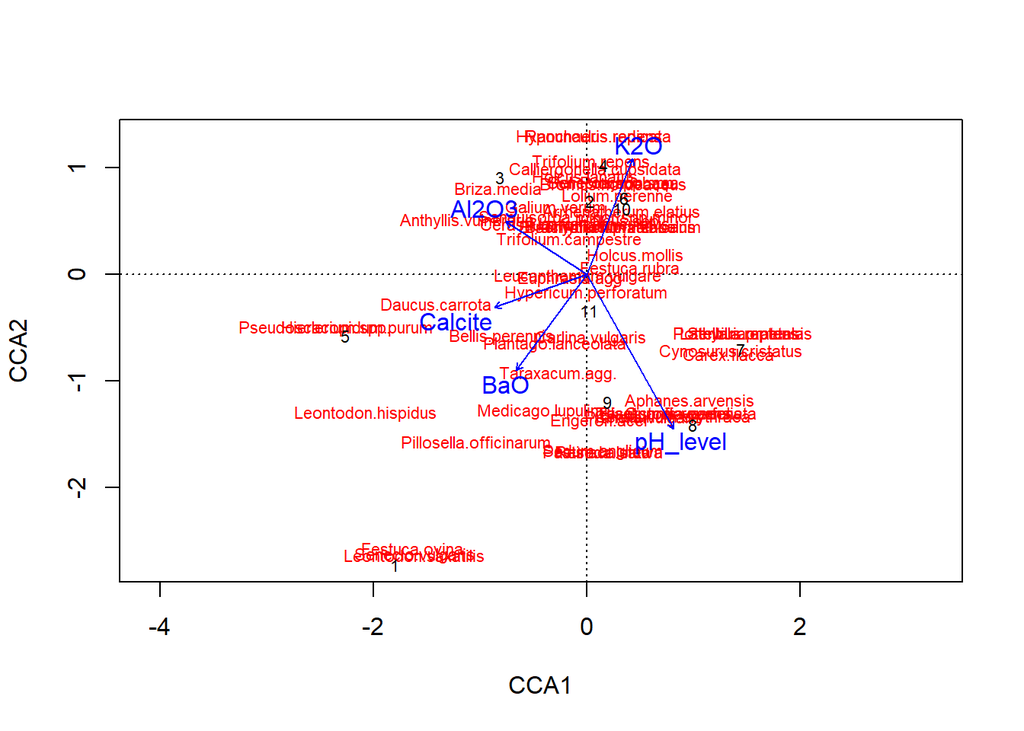

```r
plot(BarrowCCA1.4)
```

#F statistic of 1.4032 and p value of 0.003

```r
BarrowCCA1.5 <-cca(BarrowPSna ~ pH_level + K2O + Al2O3 + BaO + Ni + Pb + Calcite,
                   data = BarrowPC)

print(BarrowCCA1.5)
```

```
## Call: cca(formula = BarrowPSna ~ pH_level + K2O + Al2O3 + BaO + Ni + Pb
## + Calcite, data = BarrowPC)
##
##               Inertia Proportion Rank
## Total          4.7843     1.0000
## Constrained    3.8385     0.8023    7
## Unconstrained  0.9458     0.1977    3
## Inertia is scaled Chi-square
## 88 species (variables) deleted due to missingness
##
## Eigenvalues for constrained axes:
##   CCA1   CCA2   CCA3   CCA4   CCA5   CCA6   CCA7
## 0.7987 0.7205 0.6123 0.5664 0.5006 0.3367 0.3033
##
## Eigenvalues for unconstrained axes:
##    CA1    CA2    CA3
## 0.4613 0.3326 0.1519
```

```r
summary(BarrowCCA1.5)
```

```
##
## Call:
## cca(formula = BarrowPSna ~ pH_level + K2O + Al2O3 + BaO + Ni +      Pb + Calcite, data = BarrowPC)
##
## Partitioning of scaled Chi-square:
##               Inertia Proportion
## Total          4.7843     1.0000
## Constrained    3.8385     0.8023
## Unconstrained  0.9458     0.1977
##
## Eigenvalues, and their contribution to the scaled Chi-square
##
## Importance of components:
##                         CCA1   CCA2   CCA3   CCA4   CCA5    CCA6   CCA7     CA1
## Eigenvalue            0.7987 0.7205 0.6123 0.5664 0.5006 0.33667 0.3033 0.46130
## Proportion Explained  0.1669 0.1506 0.1280 0.1184 0.1046 0.07037 0.0634 0.09642
## Cumulative Proportion 0.1669 0.3175 0.4455 0.5639 0.6685 0.73892 0.8023 0.89874
##                           CA2     CA3
## Eigenvalue            0.33262 0.15186
## Proportion Explained  0.06952 0.03174
## Cumulative Proportion 0.96826 1.00000
##
## Accumulated constrained eigenvalues
## Importance of components:
##                         CCA1   CCA2   CCA3   CCA4   CCA5    CCA6    CCA7
## Eigenvalue            0.7987 0.7205 0.6123 0.5664 0.5006 0.33667 0.30333
## Proportion Explained  0.2081 0.1877 0.1595 0.1476 0.1304 0.08771 0.07902
## Cumulative Proportion 0.2081 0.3958 0.5553 0.7028 0.8333 0.92098 1.00000
##
## Scaling 2 for species and site scores
## * Species are scaled proportional to eigenvalues
## * Sites are unscaled: weighted dispersion equal on all dimensions
##
##
## Species scores
##
##                                 CCA1     CCA2     CCA3      CCA4     CCA5
## Anthyllis.vulneraria        -1.17960  0.29876  1.24774  0.606278 -0.19472
## Aphanes.arvensis             1.28267 -1.10325  0.94137 -0.507153  0.51171
## Arrhenatherum.elatius        0.31190  0.82680 -0.82419 -0.761931 -0.41618
```

[output cut: 137 more lines]

```
## 9  -0.32045  0.01367 -1.9430  0.336876  3.64513  0.35126
## 10  0.33586  0.77038 -1.1777 -0.570134  0.25331 -0.03701
## 11 -0.08185  0.01844 -0.9299  0.007417  0.59036 -4.06004
##
##
## Biplot scores for constraining variables
##
##             CCA1     CCA2    CCA3     CCA4    CCA5     CCA6
## pH_level  0.4777 -0.62614 -0.2386  0.02773  0.4551 -0.33872
## K2O       0.2078  0.48176  0.6545  0.28905 -0.3103  0.31646
## Al2O3    -0.3913  0.10068  0.7963  0.23116 -0.2555  0.08453
## BaO      -0.3281 -0.45189 -0.4696 -0.18697  0.1022 -0.62815
## Ni       -0.1053  0.47840  0.6946  0.44464 -0.1186  0.16492
## Pb        0.3139  0.04416 -0.3025 -0.62861 -0.4656  0.24149
## Calcite  -0.4412 -0.15222  0.4678  0.01344  0.5319 -0.18930
```

```r
anova(BarrowCCA1.5)
```

```
## Permutation test for cca under reduced model
## Permutation: free
## Number of permutations: 999
##
## Model: cca(formula = BarrowPSna ~ pH_level + K2O + Al2O3 + BaO + Ni + Pb + Calcite, data = BarrowPC)
##          Df ChiSquare      F Pr(>F)
## Model     7    3.8385 1.7394  0.001 ***
## Residual  3    0.9458
## ---
## Signif. codes:  0 '***' 0.001 '**' 0.01 '*' 0.05 '.' 0.1 ' ' 1
```

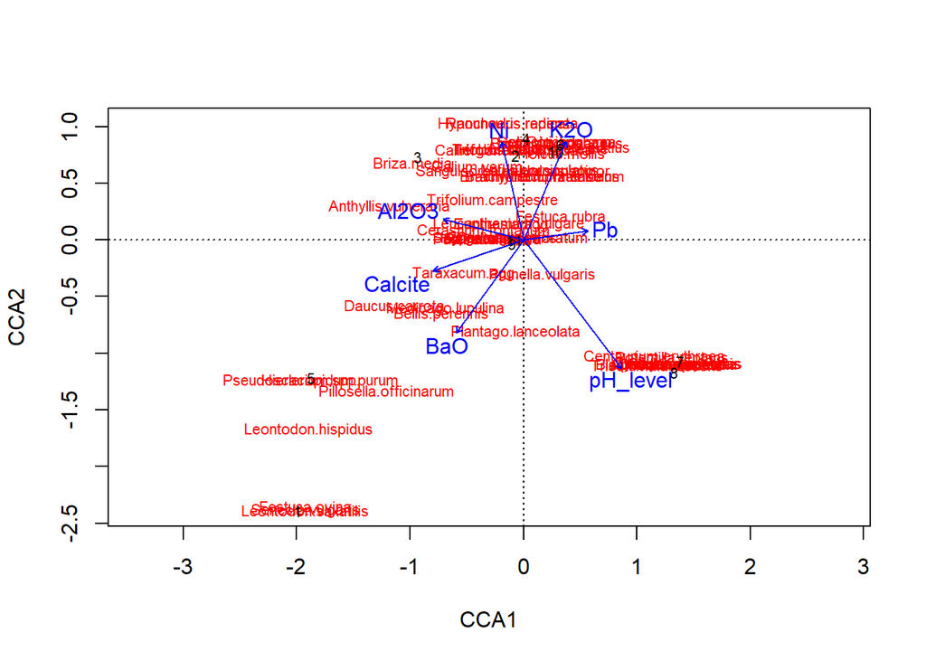

```r
plot(BarrowCCA1.5)
```

#F statistic of 1.7394 and p value of 0.001

```r
BarrowCCA1.6 <-cca(BarrowPSna ~ pH_level + K2O + Al2O3 + BaO + Ni + Cd + Calcite,
                   data = BarrowPC)

print(BarrowCCA1.6)
```

```
## Call: cca(formula = BarrowPSna ~ pH_level + K2O + Al2O3 + BaO + Ni + Cd
## + Calcite, data = BarrowPC)
##
##               Inertia Proportion Rank
## Total          4.7843     1.0000
## Constrained    3.8560     0.8060    7
## Unconstrained  0.9283     0.1940    3
## Inertia is scaled Chi-square
## 88 species (variables) deleted due to missingness
##
## Eigenvalues for constrained axes:
##   CCA1   CCA2   CCA3   CCA4   CCA5   CCA6   CCA7
## 0.8015 0.7106 0.6127 0.5519 0.5237 0.3381 0.3173
##
## Eigenvalues for unconstrained axes:
##    CA1    CA2    CA3
## 0.4574 0.3237 0.1472
```

```r
summary(BarrowCCA1.6)
```

```
##
## Call:
## cca(formula = BarrowPSna ~ pH_level + K2O + Al2O3 + BaO + Ni +      Cd + Calcite, data = BarrowPC)
##
## Partitioning of scaled Chi-square:
##               Inertia Proportion
## Total          4.7843      1.000
## Constrained    3.8560      0.806
## Unconstrained  0.9283      0.194
##
## Eigenvalues, and their contribution to the scaled Chi-square
##
## Importance of components:
##                         CCA1   CCA2   CCA3   CCA4   CCA5    CCA6    CCA7    CA1
## Eigenvalue            0.8015 0.7106 0.6127 0.5519 0.5237 0.33813 0.31735 0.4574
## Proportion Explained  0.1675 0.1485 0.1281 0.1154 0.1095 0.07068 0.06633 0.0956
## Cumulative Proportion 0.1675 0.3161 0.4441 0.5595 0.6690 0.73964 0.80597 0.9016
##                           CA2     CA3
## Eigenvalue            0.32372 0.14722
## Proportion Explained  0.06766 0.03077
## Cumulative Proportion 0.96923 1.00000
##
## Accumulated constrained eigenvalues
## Importance of components:
##                         CCA1   CCA2   CCA3   CCA4   CCA5    CCA6   CCA7
## Eigenvalue            0.8015 0.7106 0.6127 0.5519 0.5237 0.33813 0.3173
## Proportion Explained  0.2079 0.1843 0.1589 0.1431 0.1358 0.08769 0.0823
## Cumulative Proportion 0.2079 0.3922 0.5510 0.6942 0.8300 0.91770 1.0000
##
## Scaling 2 for species and site scores
## * Species are scaled proportional to eigenvalues
## * Sites are unscaled: weighted dispersion equal on all dimensions
##
##
## Species scores
##
##                                  CCA1     CCA2    CCA3     CCA4      CCA5
## Anthyllis.vulneraria        -1.196673  0.25703  1.3358  0.11163  0.163830
## Aphanes.arvensis             1.307287 -1.22832  0.5465  0.92436  0.021926
## Arrhenatherum.elatius        0.359247  0.80072 -0.9779  0.09704 -0.690327
```

[output cut: 137 more lines]

```
## 9  -0.218208  0.08132 -2.3002  0.95059  3.25631  0.299436
## 10  0.324775  0.65172 -1.2529 -0.33438  0.05875  0.248640
## 11 -0.001885  0.17225 -1.0092  0.25933  0.49982 -3.914010
##
##
## Biplot scores for constraining variables
##
##             CCA1     CCA2    CCA3      CCA4     CCA5    CCA6
## pH_level  0.4848 -0.60826 -0.2982  0.055793  0.41835 -0.3577
## K2O       0.1922  0.45178  0.7712 -0.052329 -0.13356  0.3635
## Al2O3    -0.4062  0.05799  0.8318  0.060938 -0.10057  0.1751
## BaO      -0.3199 -0.42922 -0.5428 -0.052994  0.04712 -0.5766
## Ni       -0.1179  0.46020  0.8185 -0.009981  0.11526  0.2289
## Cd        0.2440  0.14228 -0.4494  0.013993 -0.60797  0.3831
## Calcite  -0.4359 -0.18629  0.3434  0.464139  0.33700 -0.3319
```

```r
anova(BarrowCCA1.6)
```

```
## Permutation test for cca under reduced model
## Permutation: free
## Number of permutations: 999
##
## Model: cca(formula = BarrowPSna ~ pH_level + K2O + Al2O3 + BaO + Ni + Cd + Calcite, data = BarrowPC)
##          Df ChiSquare      F Pr(>F)
## Model     7    3.8560 1.7802  0.001 ***
## Residual  3    0.9283
## ---
## Signif. codes:  0 '***' 0.001 '**' 0.01 '*' 0.05 '.' 0.1 ' ' 1
```

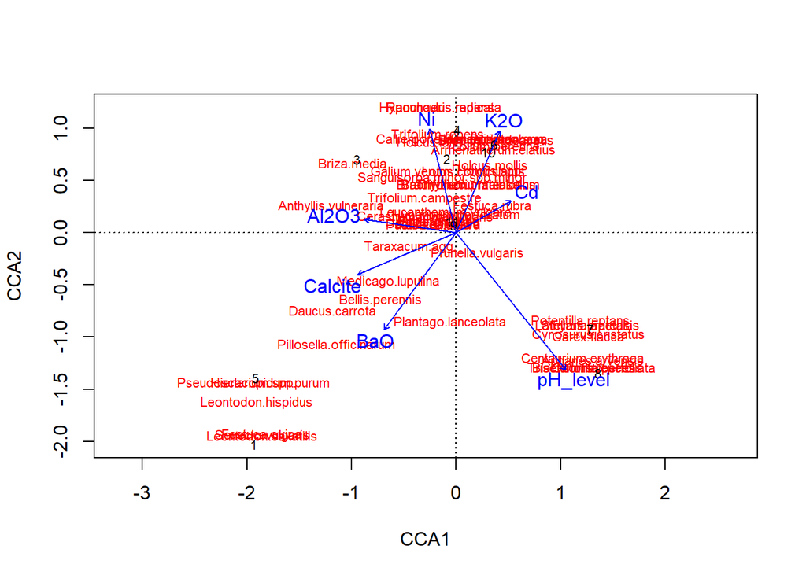

```r
plot(BarrowCCA1.6)
```

```r
BarrowCCA1.7 <-cca(BarrowPSna ~ pH_level + K2O + Al2O3 + BaO + Ni + As + Calcite,
                   data = BarrowPC)

print(BarrowCCA1.7)
```

```
## Call: cca(formula = BarrowPSna ~ pH_level + K2O + Al2O3 + BaO + Ni + As
## + Calcite, data = BarrowPC)
##
##               Inertia Proportion Rank
## Total          4.7843     1.0000
## Constrained    3.7660     0.7872    7
## Unconstrained  1.0183     0.2128    3
## Inertia is scaled Chi-square
## 88 species (variables) deleted due to missingness
##
## Eigenvalues for constrained axes:
##   CCA1   CCA2   CCA3   CCA4   CCA5   CCA6   CCA7
## 0.8130 0.7057 0.6142 0.5347 0.4617 0.3366 0.3001
##
## Eigenvalues for unconstrained axes:
##    CA1    CA2    CA3
## 0.4719 0.3936 0.1527
```

```r
summary(BarrowCCA1.7)
```

```
##
## Call:
## cca(formula = BarrowPSna ~ pH_level + K2O + Al2O3 + BaO + Ni +      As + Calcite, data = BarrowPC)
##
## Partitioning of scaled Chi-square:
##               Inertia Proportion
## Total           4.784     1.0000
## Constrained     3.766     0.7872
## Unconstrained   1.018     0.2128
##
## Eigenvalues, and their contribution to the scaled Chi-square
##
## Importance of components:
##                         CCA1   CCA2   CCA3   CCA4   CCA5    CCA6    CCA7
## Eigenvalue            0.8130 0.7057 0.6142 0.5347 0.4617 0.33662 0.30013
## Proportion Explained  0.1699 0.1475 0.1284 0.1118 0.0965 0.07036 0.06273
## Cumulative Proportion 0.1699 0.3174 0.4458 0.5576 0.6541 0.72443 0.78716
##                           CA1     CA2     CA3
## Eigenvalue            0.47193 0.39363 0.15273
## Proportion Explained  0.09864 0.08228 0.03192
## Cumulative Proportion 0.88580 0.96808 1.00000
##
## Accumulated constrained eigenvalues
## Importance of components:
##                         CCA1   CCA2   CCA3   CCA4   CCA5    CCA6    CCA7
## Eigenvalue            0.8130 0.7057 0.6142 0.5347 0.4617 0.33662 0.30013
## Proportion Explained  0.2159 0.1874 0.1631 0.1420 0.1226 0.08938 0.07969
## Cumulative Proportion 0.2159 0.4033 0.5663 0.7083 0.8309 0.92031 1.00000
##
## Scaling 2 for species and site scores
## * Species are scaled proportional to eigenvalues
## * Sites are unscaled: weighted dispersion equal on all dimensions
##
##
## Species scores
##
##                                 CCA1     CCA2     CCA3      CCA4     CCA5
## Anthyllis.vulneraria        -1.11296  0.16154  1.39802  0.220850  0.16116
## Aphanes.arvensis             1.49572 -1.26874  0.74619  0.019850 -0.41775
## Arrhenatherum.elatius        0.29488  0.66173 -0.80591 -0.833906  0.11230
```

[output cut: 137 more lines]

```
## 9  -0.19921 -0.27202 -1.95784  2.3121 -2.69251 -0.35553
## 10  0.36827  0.56570 -1.14702 -0.2989 -0.32426  0.05843
## 11 -0.10972  0.06548 -0.92660  0.3174 -0.53093  4.05551
##
##
## Biplot scores for constraining variables
##
##             CCA1     CCA2    CCA3      CCA4     CCA5     CCA6
## pH_level  0.5060 -0.56383 -0.3360  0.405460 -0.15236  0.34166
## K2O       0.1781  0.50110  0.7195 -0.008181  0.29243 -0.31298
## Al2O3    -0.3764  0.04137  0.8357  0.017884  0.28795 -0.07818
## BaO      -0.2999 -0.46822 -0.5174 -0.017629 -0.05860  0.63116
## Ni       -0.1308  0.47889  0.7790  0.208550  0.18297 -0.16135
## As       -0.2695  0.29748  0.8027  0.240525  0.04079 -0.04197
## Calcite  -0.3964 -0.27400  0.4550  0.260156 -0.50333  0.17744
```

```r
anova(BarrowCCA1.7)
```

```
## Permutation test for cca under reduced model
## Permutation: free
## Number of permutations: 999
##
## Model: cca(formula = BarrowPSna ~ pH_level + K2O + Al2O3 + BaO + Ni + As + Calcite, data = BarrowPC)
##          Df ChiSquare     F Pr(>F)
## Model     7    3.7660 1.585  0.001 ***
## Residual  3    1.0183
## ---
## Signif. codes:  0 '***' 0.001 '**' 0.01 '*' 0.05 '.' 0.1 ' ' 1
```

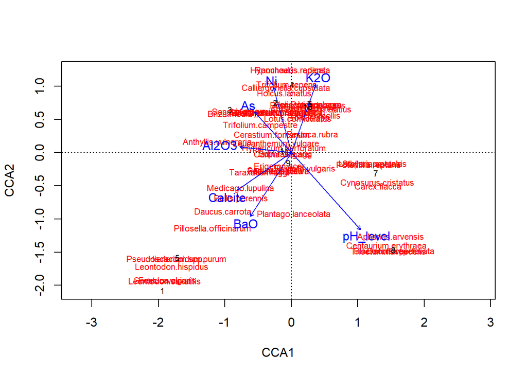

```r
plot(BarrowCCA1.7)
```

```r
BarrowCCA1.8 <-cca(BarrowPSna ~ pH_level + K2O + Al2O3 + BaO + Pb + As + Calcite,
                   data = BarrowPC)

print(BarrowCCA1.8)
```

```
## Call: cca(formula = BarrowPSna ~ pH_level + K2O + Al2O3 + BaO + Pb + As
## + Calcite, data = BarrowPC)
##
##               Inertia Proportion Rank
## Total          4.7843     1.0000
## Constrained    3.8046     0.7952    7
## Unconstrained  0.9797     0.2048    3
## Inertia is scaled Chi-square
## 88 species (variables) deleted due to missingness
##
## Eigenvalues for constrained axes:
##   CCA1   CCA2   CCA3   CCA4   CCA5   CCA6   CCA7
## 0.7980 0.6957 0.6118 0.5705 0.4903 0.3365 0.3017
##
## Eigenvalues for unconstrained axes:
##    CA1    CA2    CA3
## 0.4735 0.3520 0.1542
```

```r
summary(BarrowCCA1.8)
```

```
##
## Call:
## cca(formula = BarrowPSna ~ pH_level + K2O + Al2O3 + BaO + Pb +      As + Calcite, data = BarrowPC)
##
## Partitioning of scaled Chi-square:
##               Inertia Proportion
## Total          4.7843     1.0000
## Constrained    3.8046     0.7952
## Unconstrained  0.9797     0.2048
##
## Eigenvalues, and their contribution to the scaled Chi-square
##
## Importance of components:
##                         CCA1   CCA2   CCA3   CCA4   CCA5    CCA6    CCA7
## Eigenvalue            0.7980 0.6957 0.6118 0.5705 0.4903 0.33654 0.30172
## Proportion Explained  0.1668 0.1454 0.1279 0.1193 0.1025 0.07034 0.06307
## Cumulative Proportion 0.1668 0.3122 0.4401 0.5593 0.6618 0.73217 0.79523
##                           CA1     CA2     CA3
## Eigenvalue            0.47352 0.35195 0.15420
## Proportion Explained  0.09897 0.07356 0.03223
## Cumulative Proportion 0.89421 0.96777 1.00000
##
## Accumulated constrained eigenvalues
## Importance of components:
##                         CCA1   CCA2   CCA3   CCA4   CCA5    CCA6   CCA7
## Eigenvalue            0.7980 0.6957 0.6118 0.5705 0.4903 0.33654 0.3017
## Proportion Explained  0.2098 0.1829 0.1608 0.1500 0.1289 0.08846 0.0793
## Cumulative Proportion 0.2098 0.3926 0.5534 0.7034 0.8322 0.92070 1.0000
##
## Scaling 2 for species and site scores
## * Species are scaled proportional to eigenvalues
## * Sites are unscaled: weighted dispersion equal on all dimensions
##
##
## Species scores
##
##                                 CCA1     CCA2     CCA3     CCA4     CCA5
## Anthyllis.vulneraria        -1.12878  0.54378  1.18637  0.62612 -0.05542
## Aphanes.arvensis             1.17153 -1.16928  1.08721 -0.48509  0.26460
## Arrhenatherum.elatius        0.44505  0.69627 -0.83032 -0.79669 -0.38704
```

[output cut: 137 more lines]

```
## 9  -0.01607 -0.66325 -1.4889 -0.20124  3.74910  0.37049
## 10  0.52870  0.50487 -1.0906 -0.72157  0.33331 -0.04772
## 11 -0.06072 -0.08222 -0.8828 -0.09414  0.70281 -4.05090
##
##
## Biplot scores for constraining variables
##
##             CCA1     CCA2    CCA3      CCA4    CCA5     CCA6
## pH_level  0.4194 -0.74545 -0.1520 -0.007057  0.3500 -0.34501
## K2O       0.2457  0.52844  0.5771  0.352477 -0.2954  0.31384
## Al2O3    -0.3883  0.22311  0.7508  0.286418 -0.2652  0.07955
## BaO      -0.3692 -0.45562 -0.4167 -0.227598  0.0923 -0.63038
## Pb        0.3102  0.02212 -0.3071 -0.596142 -0.5333  0.22913
## As       -0.2292  0.42043  0.6873  0.407815  0.0674  0.04701
## Calcite  -0.4402 -0.10492  0.5122 -0.008526  0.5119 -0.17950
```

```r
anova(BarrowCCA1.8)
```

```
## Permutation test for cca under reduced model
## Permutation: free
## Number of permutations: 999
##
## Model: cca(formula = BarrowPSna ~ pH_level + K2O + Al2O3 + BaO + Pb + As + Calcite, data = BarrowPC)
##          Df ChiSquare      F Pr(>F)
## Model     7    3.8046 1.6644  0.001 ***
## Residual  3    0.9797
## ---
## Signif. codes:  0 '***' 0.001 '**' 0.01 '*' 0.05 '.' 0.1 ' ' 1
```

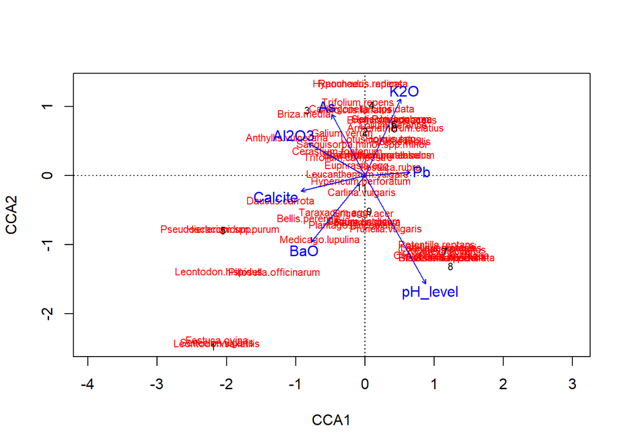

```r
plot(BarrowCCA1.8)
```

```r
BarrowCCA2 <- cca(BarrowPSna ~ Na2O + pH_level + MgO + CaO + Al2O3 + Cr2O3, data = BarrowPC)

print(BarrowCCA2)
```

```
## Call: cca(formula = BarrowPSna ~ Na2O + pH_level + MgO + CaO + Al2O3 +
## Cr2O3, data = BarrowPC)
##
##               Inertia Proportion Rank
## Total          4.7843     1.0000
## Constrained    3.3915     0.7089    6
## Unconstrained  1.3928     0.2911    4
## Inertia is scaled Chi-square
## 88 species (variables) deleted due to missingness
##
## Eigenvalues for constrained axes:
##   CCA1   CCA2   CCA3   CCA4   CCA5   CCA6
## 0.8022 0.6645 0.6288 0.5407 0.4594 0.2958
##
## Eigenvalues for unconstrained axes:
##    CA1    CA2    CA3    CA4
## 0.5675 0.3797 0.3068 0.1388
```

```r
summary(BarrowCCA2)
```

```
##
## Call:
## cca(formula = BarrowPSna ~ Na2O + pH_level + MgO + CaO + Al2O3 +      Cr2O3, data = BarrowPC)
##
## Partitioning of scaled Chi-square:
##               Inertia Proportion
## Total           4.784     1.0000
## Constrained     3.392     0.7089
## Unconstrained   1.393     0.2911
##
## Eigenvalues, and their contribution to the scaled Chi-square
##
## Importance of components:
##                         CCA1   CCA2   CCA3   CCA4    CCA5    CCA6    CA1
## Eigenvalue            0.8022 0.6645 0.6288 0.5407 0.45942 0.29580 0.5675
## Proportion Explained  0.1677 0.1389 0.1314 0.1130 0.09603 0.06183 0.1186
## Cumulative Proportion 0.1677 0.3066 0.4380 0.5510 0.64706 0.70889 0.8275
##                           CA2     CA3     CA4
## Eigenvalue            0.37966 0.30684 0.13880
## Proportion Explained  0.07935 0.06413 0.02901
## Cumulative Proportion 0.90685 0.97099 1.00000
##
## Accumulated constrained eigenvalues
## Importance of components:
##                         CCA1   CCA2   CCA3   CCA4   CCA5    CCA6
## Eigenvalue            0.8022 0.6645 0.6288 0.5407 0.4594 0.29580
## Proportion Explained  0.2365 0.1959 0.1854 0.1594 0.1355 0.08722
## Cumulative Proportion 0.2365 0.4325 0.6179 0.7773 0.9128 1.00000
##
## Scaling 2 for species and site scores
## * Species are scaled proportional to eigenvalues
## * Sites are unscaled: weighted dispersion equal on all dimensions
##
##
## Species scores
##
##                                  CCA1      CCA2     CCA3      CCA4     CCA5
## Anthyllis.vulneraria        -1.051761  0.009255  1.32631 -0.922740  0.25734
## Aphanes.arvensis             1.562037  1.169623  0.50295  0.030767  0.02000
## Arrhenatherum.elatius        0.017632 -0.963717 -0.68473  0.657681  0.69372
```

[output cut: 136 more lines]

```
## 8   1.57897  1.39173  0.61451  0.10388 -0.01445  0.41154
## 9  -0.17684 -1.31273 -1.04317 -1.37645 -4.59765  0.22493
## 10  0.17305 -0.92040 -1.07386  0.41018  0.22989 -1.44037
## 11 -0.49302  1.10276 -1.05715 -0.07120 -1.97832 -0.66532
##
##
## Biplot scores for constraining variables
##
##             CCA1     CCA2    CCA3     CCA4    CCA5     CCA6
## Na2O      0.1768 -0.41994  0.3570 -0.44213  0.6844 -0.03247
## pH_level  0.5309  0.56287 -0.3789 -0.05892 -0.4843 -0.14058
## MgO      -0.1121  0.46888 -0.6878 -0.23896  0.3066 -0.37876
## CaO      -0.3161  0.46938 -0.4860 -0.01764 -0.6658 -0.00702
## Al2O3    -0.3304  0.03337  0.7850 -0.34437  0.3559 -0.16790
## Cr2O3    -0.0749 -0.36140  0.7183 -0.39163  0.4121 -0.15717
```

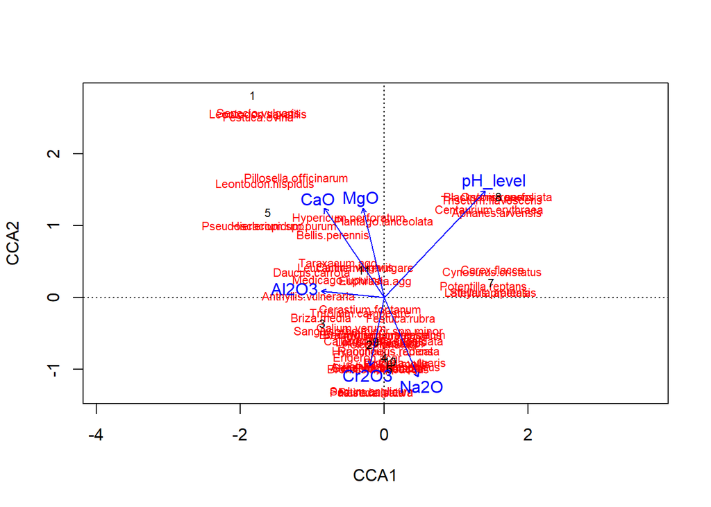

```r
plot(BarrowCCA2)
```

```r
anova(BarrowCCA2)
```

```
## Permutation test for cca under reduced model
## Permutation: free
## Number of permutations: 999
##
## Model: cca(formula = BarrowPSna ~ Na2O + pH_level + MgO + CaO + Al2O3 + Cr2O3, data = BarrowPC)
##          Df ChiSquare      F Pr(>F)
## Model     6    3.3915 1.6234  0.004 **
## Residual  4    1.3928
## ---
## Signif. codes:  0 '***' 0.001 '**' 0.01 '*' 0.05 '.' 0.1 ' ' 1
```

#To better visualise the BarrowCCA1.5 graph…

```r
BarrowCCA1.5$CCA$v
```

```
##                                    CCA1        CCA2        CCA3         CCA4
## Anthyllis.vulneraria        -1.31992226  0.35196983  1.59454956  0.805584062
## Aphanes.arvensis             1.43524500 -1.29975578  1.20301529 -0.673872397
## Arrhenatherum.elatius        0.34900220  0.97406553 -1.05327062 -1.012406217
## Bellis.perennis             -0.81385547 -0.76799626 -0.19148345 -0.238261508
## Blackstonia.perfoliata       1.41187050 -1.30174186  1.55528205 -1.238921351
## Brachythecium.albicans       0.18589242  0.65940225  0.35204116  0.053732184
## Brachythecium.rutabulum      0.18589242  0.65940225  0.35204116  0.053732184
## Briza.media                 -1.09459018  0.80405141  1.79762243  1.262237460
## Bromus.hordeaceus            0.33224801  1.01560971 -0.77093642 -1.171686523
## Calliergonella.cupsidata    -0.10567042  0.92931263 -0.21916756  0.647733758
## Carex.flacca                 1.51705574 -1.29280450 -0.02991837  1.303798939
## Carlina.vulgaris            -0.16786987  0.02011890 -1.55824919  0.134930456
## Centaurium.erythraea         1.29384121 -1.21388551  1.28606154 -1.126485255
## Cerastium.fontanum          -0.39094544  0.11423162  0.04083075  0.513580100
## Cynosurus.cristatus          1.52162901 -1.29241592 -0.09884012  1.414351995
## Daucus.carrota              -1.27347619 -0.67404861 -0.35346737 -1.668651778
## Erigeron.acer               -0.30689566  0.01719148 -2.23244103  0.362891275
## Euphrasia.agg               -0.22113571  0.16584142  1.01574755  0.450179433
## Festuca.ovina               -2.14969720 -2.76649193 -1.99845032  1.848136167
## Festuca.rubra                0.37320766  0.25473940 -0.79332195  0.004249092
## Galium.verum                -0.45936916  0.77376118  1.17265433  0.750934270
## Helicotrichon.spp.           0.33224801  1.01560971 -0.77093642 -1.171686523
## Hieracium.spp.              -2.09811873 -1.46487034  0.22230161 -2.124198803
## Holcus.spp.                  0.34895828  0.71088243 -0.58370541 -0.628604577
## Holcus.lanatus              -0.16773014  0.94795820 -0.58440680  0.175239798
## Holcus.mollis                0.37580891  0.90759485 -1.50500535 -0.757557728
## Hypericum.perforatum        -0.09159023  0.02172509 -1.18833863  0.009854608
## Hypochaeris.radicata        -0.15553429  1.20831795 -0.75771353  0.516778727
## Lathyrus.pratensis           1.55211749 -1.28982538 -0.55831851  2.151372369
## Leontodon.hispidus          -2.11804678 -1.96776959 -0.63571618 -0.589433019
## Leontodon.saxatilis         -2.15126019 -2.80593501 -2.06574583  1.968509954
## Leucanthemum.vulgare        -0.14704520  0.16616733 -0.70214468 -0.145969404
## Lolium.perenne               0.34582152  0.93954634 -0.84188628 -1.044501683
## Lotus.corniculatus           0.15923304  0.73617064 -0.54899615 -0.584711877
## Medicago.lupulina           -0.77464558 -0.71014312 -1.39891009  0.823287405
## Ononis.repens                1.41187050 -1.30174186  1.55528205 -1.238921351
## Pastinaca.sativa            -0.35856896  0.01610341 -2.48302561  0.447620076
## Pillosella.officinarum      -1.35065510 -1.56366488 -1.59634929  0.843982524
## Plantago.lanceolata         -0.07813979 -0.95244867  0.12094166 -0.790842427
```

[output cut: 148 more lines]

```
##                        121                        125
##          Stachys.sylvatica      Thuidium.tamariscinum
##                        126                        129
##         Thymus.polytrichus     Trichostomum.crispulum
##                        130                        131
##           Trifolium.dubium          Tussilago.farfara
##                        133                        137
##              Urtica.diocia       Veronica.officinalis
##                        138                        139
##               Vicia.sativa            Viola.riviniana
##                        140                        141
##        Weissia.controversa          Zygodon.stirtonii
##                        142                        143
## attr(,"class")
## [1] "exclude"
```

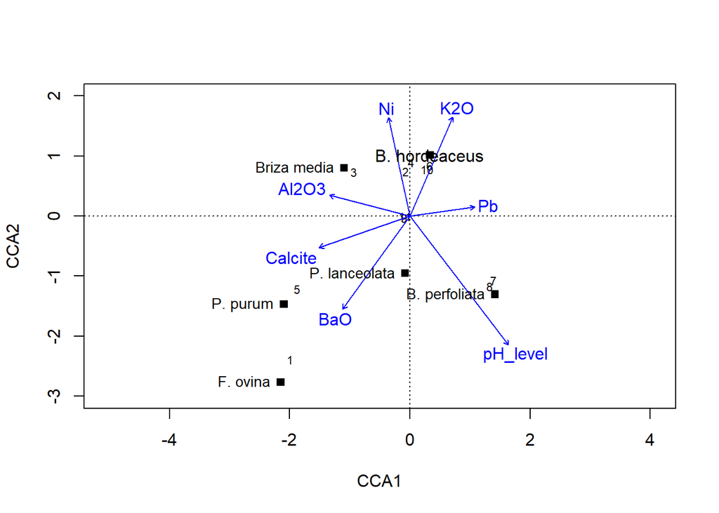

```r
plot(BarrowCCA1.5, choices = c(1,2), display = c("wa", "bp"), xlim = c(-4, 3),
     ylim = c(-3, 2))


#Increasing the xlim and ylim to give more room for writing on graph

points(x = -2.09811873, y = -1.46487034, pch = 15, col = "black")

#This point represents Pseudoscleropodium purum

text('P. purum', x = -2.09811873, y = -1.46487034, cex = 0.88, pos = 2, col = "black")

#Adding text for Pseudoscleropodium purum

points(x = -1.09459018, y = 0.80405141, pch = 15, col = "black")

#This point represents Briza media

text('Briza media', x = -1.09459018, y = 0.80405141, cex = 0.88, pos = 2, col = "black")

#Adding text for Briza media

points(x = -0.07813979, y = -0.95244867, pch = 15, col = "black")

#This point represents Plantago lanceolata

text('P. lanceolata', x = -0.07813979, y = -0.95244867, cex = 0.88, pos = 2, col = "black")

#Adding text for Plantago lanceolata

points(x = -2.14969720, y = -2.76649193, pch = 15, col = "black")

#This point represents Festuca ovina

text('F. ovina', x = -2.14969720, y = -2.76649193, cex = 0.88, pos = 2, col = "black")

#TAdding text for Festuca ovina

points(x = 1.41187050, y = -1.30174186, pch = 15, col = "black")

#This point represents Blackstonia perfoliata

text('B. perfoliata', x = 1.41187050, y = -1.30174186, cex = 0.88, pos = 2, col = "black")

#Adding text for Blackstonia perfoliata

points(x = 0.33224801, y = 1.01560971, pch = 15, col = "black")

#This point represents Bromus hordeaceus

text('B. hordeaceus', x = 0.33224801, y = 1.01560971, pch = 15, col = "black")
```

```r
#Adding text for Bromus hordeaceus
```